# Part II - Do Your Friends Give You Better Student Loan Deals?

## Investigation Overview

Overall, my project looked at whether having higher amounts of friends as investors in your student loan would get you a better deal, either in term length, or expected yield.

Insights:

> There are no strong correlations between Term Length and Estimated Yield

> There is no strong correlation between Term Length or FriendInvestorCount.

> There is a weak negative correlation between Friend Investor Count and Estimated Yield but could be a result of narrowing ranges.

> student loans are overwhelmingly not financed by friends

## Dataset Overview and Executive Summary

The dataset contains 81 variables, and looks at student loan data. There are 113,937 loans to use as data points. I look at the variables Term, EstimatedEffectiveYield, and InvestmentFromFriendsCount.

```python
# import all packages and set plots to be embedded inline
import numpy as np
import pandas as pd
import matplotlib.pyplot as plt
import seaborn as sns

# suppress warnings from final output
import warnings
warnings.simplefilter("ignore")
```

```python
# load in the dataset into a pandas dataframe

url = 'https://s3.amazonaws.com/udacity-hosted-downloads/ud651/prosperLoanData.csv'
df = pd.read_csv(url)
```

## Scatterplot of Term Versus Effective Yield

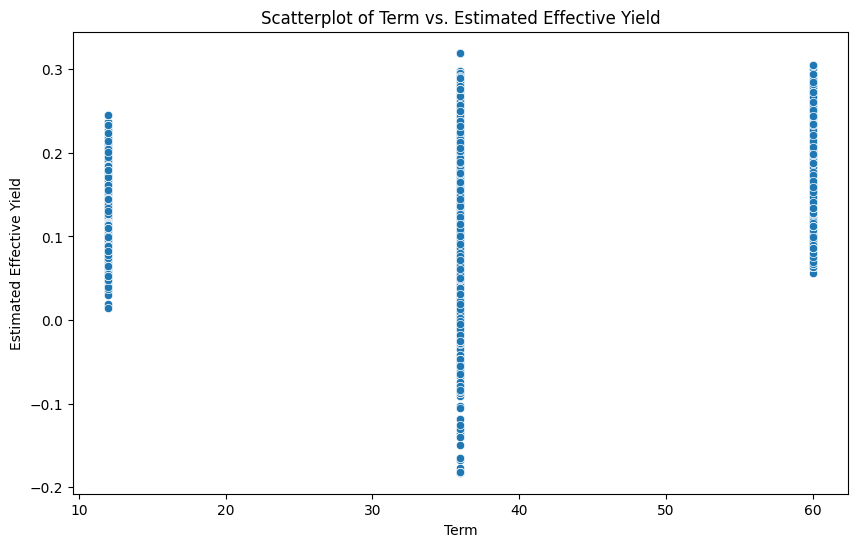

```python
# Scatterplot: Term vs. EstimatedEffectiveYield
plt.figure(figsize=(10, 6))
sns.scatterplot(data=df, x='Term', y='EstimatedEffectiveYield')
plt.title('Scatterplot of Term vs. Estimated Effective Yield')
plt.xlabel('Term')
plt.ylabel('Estimated Effective Yield')
plt.show()
```

## Estimated Effective Yield by Investment From Friends Count

> As you increase the Investment From Friends Count, you start to notice the range narrow slightly, and appear to move slightly down, implying a very noisy negative correlation. You can also see several outliers in terms of several negative yield situations with zero friends.

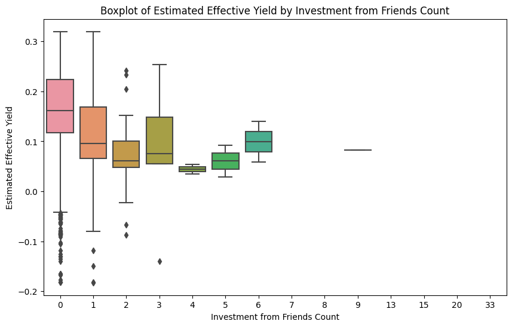

```python
# Boxplot: EstimatedEffectiveYield vs. InvestmentfromFriendsCount
plt.figure(figsize=(10, 6))
sns.boxplot(data=df, x='InvestmentFromFriendsCount', y='EstimatedEffectiveYield')
plt.title('Boxplot of Estimated Effective Yield by Investment from Friends Count')
plt.xlabel('Investment from Friends Count')
plt.ylabel('Estimated Effective Yield')
plt.show()
```

## Heatmap of Investment From Friends Count vs Term

> I thought this heatmap was insightful because it shows just how concentrated the value of zero is for Investment From Friends Count. Similarly, Term of 36 was most concentrated, and looked like 12 was the least frequent term.

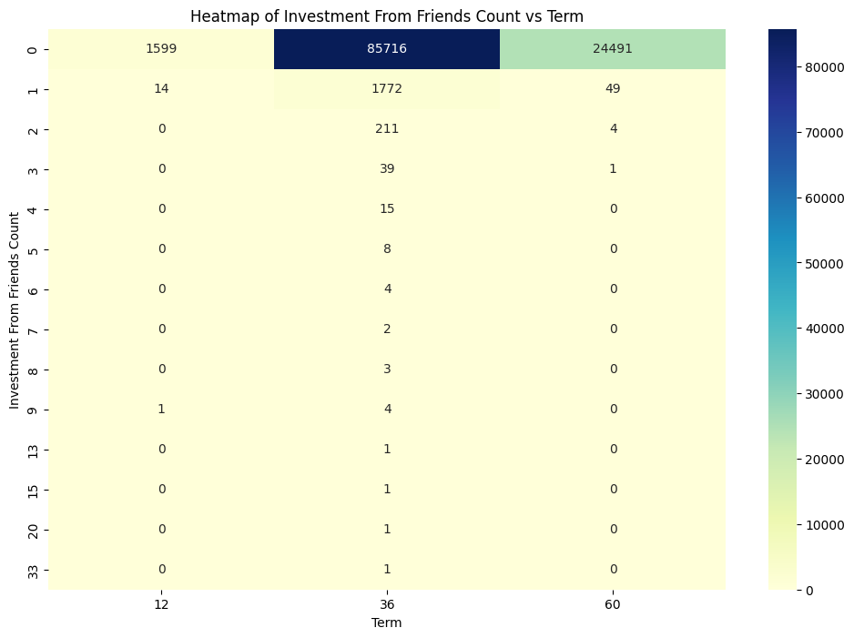

```python
# Creating a pivot table for the heatmap
heatmap_data = df.pivot_table(index='InvestmentFromFriendsCount', columns='Term', aggfunc='size', fill_value=0)

# Plotting the heatmap
plt.figure(figsize=(12, 8))
sns.heatmap(heatmap_data, annot=True, fmt="d", cmap="YlGnBu")

plt.title('Heatmap of Investment From Friends Count vs Term')
plt.xlabel('Term')
plt.ylabel('Investment From Friends Count')
plt.show()
```

### Submission

If you are using classroom workspace, you can choose from the following two ways of submission:

1. **Submit from the workspace**. Make sure you have removed the example project from the /home/workspace directory. You must submit the following files:
   - Part_I_notebook.ipynb
   - Part_I_notebook.html or pdf
   - Part_II_notebook.ipynb
   - Part_II_notebook.html or pdf
2. **Submit a zip file on the last page of this project lesson**. In this case, open the Jupyter terminal and run the command below to generate a ZIP file.

```
zip -r my_project.zip .
```

The command abobve will ZIP every file present in your /home/workspace directory. Next, you can download the zip to your local, and follow the instructions on the last page of this project lesson.